# Assesment3

Tharindu Madusanka Uyanahewa s4668998

1/24/2022

```r
library(highcharter)
library(data.table)
library(plotly)
library(randomForest)
library(yaml)
library(tidyverse)
library(knitr)
library(dplyr)
library(skimr)
library(tibble)
library(rmarkdown)
library(tidyr)
library(ggplot2)
library(ggforce)

library(widyr)
library(tidymodels)
```

#——————————————————————————————————–

# Executive Summary

#This report is beased on the Ramen and thier market analysis. There are few objectives focused in this report. According to the first objective, it refers business problem analysis and thier findings. In second objective is focused to provide information and suitable analysis for important areas of the business in order to obtain management decisions by potential investors, stakeholders, clients. Moreover, this business report includes introduction about dataset, Analysis and Modeling, Findings, Conclusions and Recommendations.

#——————————————————————————————————–

# Introduction

#Ramen is a Japanese noodle soup. It consists of Chinese-style wheat noodles served in a meat or fish-based broth, often flavored with soy sauce. This dataset is based on Ramen information which focuses on ramen ratings by source data of ramen brands, varieties, style, origin countrry and thier rates(stars).

#——————————————————————————————————–

# Business Problem

#This report will explore the final style of Ramen or stars to be obtained to the Ramen to reach certain style can be predicted.

#Major question: Does it able to predict final style of Ramen or stars

#Sub questions:

#Q1. Does it able to predict the final style of Ramen by knowing their brand and stars #Q2. Does it able to predict the stars/rates of Ramen by knowing their brand and final style

#——————————————————————————————————–

# About the dataset [Ramen data]

#The dataset indicates how various Ramens brands affects the style of Ramens with thier rating (stars) obtained. The initial Ramen consumption/sales is based on their style and rates (stars).

#There are 3180 of total data records, 453 different Ramen brands, 2963 of different Ramen varieties, 8 different Ramen packages styles, 44 different origin countries, 40 various rates/star categories

## Load the dataset

```r
ramen_ratings <- readr::read_csv("https://raw.githubusercontent.com/rfordatascience/tidytuesday/master/data/2019/2019-06-04/ramen_ratings.csv")
```

## Data Clensing

#As per the easy and meaningful understanding purposes, Data clensing is used in this dataset. Thare are some varibale names replaced with understandable names such as “stars” is replaced by variable name called “rates”, “brand” is replaced by “ramen_brand”, “variety” is replaced by “ramen_variety”, “country” is replaced by “origin_country”.

```r
ramen_ratings <- ramen_ratings %>%
  setNames(c("review_number", "ramen_brand", "ramen_variety", "ramen_style" , "origin_country", "rates"))
```

##In order to do useful analysis, it is requered to change factor variables since there are few character variables.

```r
ramen_ratings <- ramen_ratings %>%
  mutate_if(is.character, factor)
```

#In the dataset, there are 3180 records available for the analysis. According to the dataset, there are 454 different ramen brands, 9 different styles and 40 different rating categories.

#——————————————————————————————————–

# DESCRIPTIVE or EXPLORATORY ANALYSIS

#It is required to expore the data in order to conduct descriptive anlysis.

## How many various type of “ramen styles” are avilable in the data set?

```r
ramen_ratings %>%
  count(ramen_style) %>%
  kable()
```

| ramen_style | n |
| --- | --- |
| Bar | 1 |
| Bowl | 612 |
| Box | 32 |
| Can | 1 |
| Cup | 559 |
| Pack | 1832 |
| Restaurant | 3 |
| Tray | 138 |
| NA | 2 |

#According to the above results there are 9 different ramen styles including Bar,Bowl,Box,Can,Cup,Pack,Restaurant,Tray,NA. Therefore, ramen brand styles can be classified as 9 different categories.

## What is the relation between the stars/rates and the final style?

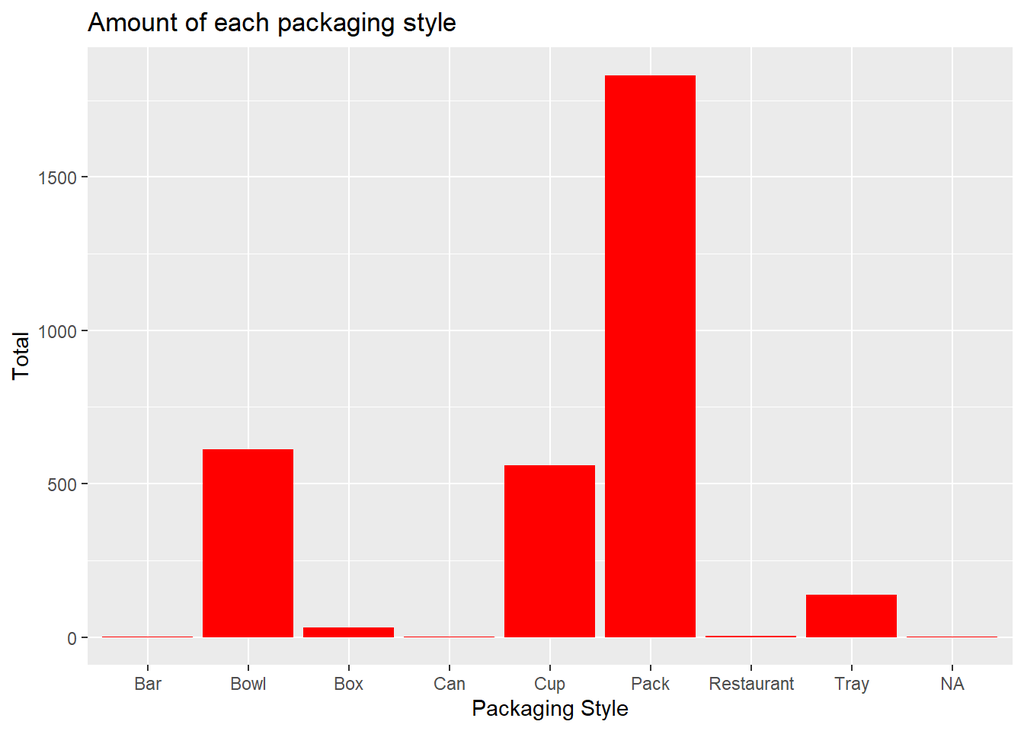

```r
ramen_chart_style <- ggplot(ramen_ratings, aes(x=ramen_style)) + geom_bar(stat="count",position="stack",fill="red")+
  labs(title = "Amount of each packaging style", x="Packaging Style",y="Total")
ramen_chart_style
```

```r
ramen_data_brands <- ramen_ratings %>%
  group_by(ramen_brand) %>%
  summarise(count = n()) %>%
  top_n(n = 10, wt = count)
ramen_data_brands
```

```
## # A tibble: 10 x 2
##    ramen_brand     count
##    <fct>           <int>
##  1 Indomie            56
##  2 Mama               71
##  3 Maruchan          106
##  4 Myojo              90
##  5 Nissin            443
##  6 Nongshim          110
##  7 Ottogi             48
##  8 Paldo              71
##  9 Samyang Foods      82
## 10 Sapporo Ichiban    44
```

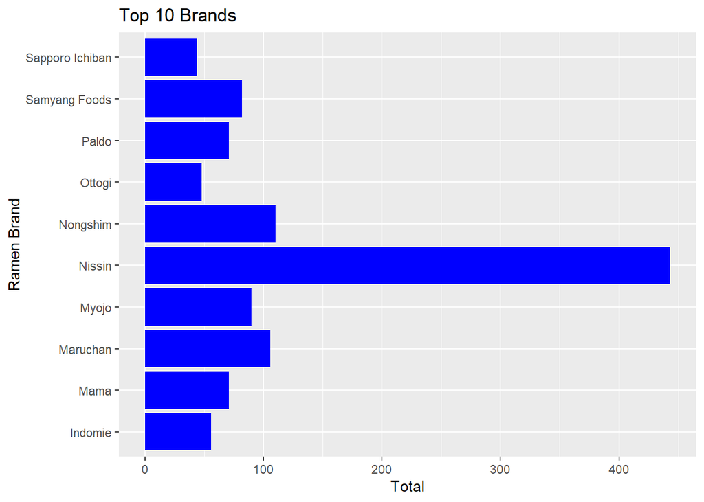

```r
ramen_chart_brands <- ggplot(ramen_data_brands, aes(x = count , y = ramen_brand, fill=count)) + geom_col(fill="blue")+
  labs(title = "Top 10 Brands", x="Total",y="Ramen Brand")
ramen_chart_brands
```

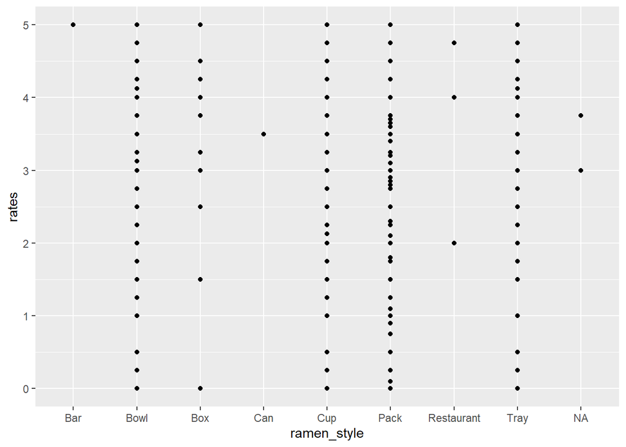

```r
ramen_ratings %>%
  ggplot(aes(ramen_style,rates)) +
  geom_point() +
  geom_smooth(method = lm, se = FALSE)
```